# Отчет по лабораторной работе №12

Отчет о настройке сети в Linux

Чилеше . Л

Российский университет дружбы народов, Москва, Россия

Объединённый институт ядерных исследований, Дубна, Россия

27 января 2003

# Информация

## Докладчик

- Лупупа Чилеше
- Студент
- Студент Группы НПИбд-03-23
- Российский университет дружбы народов

# Вводная часть

## Цель работ

Получить навыки настройки сетевых параметров системы.

## ip -s link

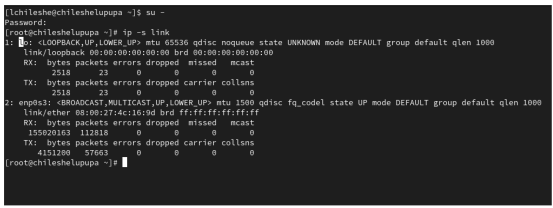

**Пояснение:** Интерфейс enp0s3 активно передаёт и принимает данные. Ошибок и потерь пакетов нет.

## ip addr show

[figure not shown]

**Пояснение:** Интерфейс enp0s3 имеет IPv4-адрес 10.0.2.15 с маской /24. Это динамически назначенный адрес.

## ping -c 4 8.8.8.8

[figure not shown]

**Вывод:** Подключение к Интернету успешно работает.

## p addr add 10.0.0.10/24 dev enp0s3

[figure not shown]

## ip addr show

[figure not shown]

## ifconfig

[figure not shown]

## ss -tul

[figure not shown]

# РУправление сетевыми подключениями с помощью nmcli

## nmcli connection

[figure not shown]

## Добавление соединения DHCP

[figure not shown]

## . Добавление статического соединения:

## nmcli connection up

## nmcli connection up

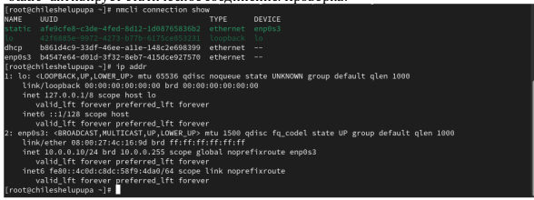

# Изменение параметров соединения с помощью nmcli

## Отключение автоподключения:

Команда nmcli connection modify “static” connection.autoconnect no.

## Добавление DNS-сервера:

Команда nmcli connection modify “static” ipv4.dns 10.0.0.10.

## Добавление второго DNS-сервера:

Команда nmcli connection modify “static” +ipv4.dns 8.8.8.8.

## Изменение IP-адреса:

Команда nmcli connection modify “static” ipv4.addresses 10.0.0.20/24.

## Добавление другого IP-адреса:

Команда nmcli connection modify “static” +ipv4.addresses 10.20.30.40/16.

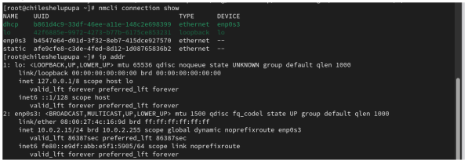

## Вывод

Проведены настройки сети согласно заданию. Основные действия включают просмотр текущего состояния интерфейсов, добавление IP-адресов и управление соединениями через nmcli. Проверка показала успешность выполнения операций.